# Bootstrapping

Statistical Programming with R

## We use the following packages

```r
library(dplyr)    # Data manipulation
library(magrittr) # Pipes
library(ggplot2)  # Plotting suite
library(boot)     # Bootstrapping functions
```

[figure not shown]

## Running example

- a country called sumR
- 3 million adult humans inhabit it
- 3 cities Rnhem, AlkmR, and LeeuwRden
- height
- shoe size

```r
set.seed(54321)

height   <- rnorm(3e6, mean = 180, sd = 7.5)
shoesize <- 35 + 0.02*height + runif(3e6, -1, 1)
city     <- sample(c("Rnhem", "AlkmR", "LeeuwRden"), size = 3e6,
                   prob = c(0.6, 0.3, 0.1), replace = TRUE)

sumR <- data.frame(height, shoesize, city)
```

## Running example

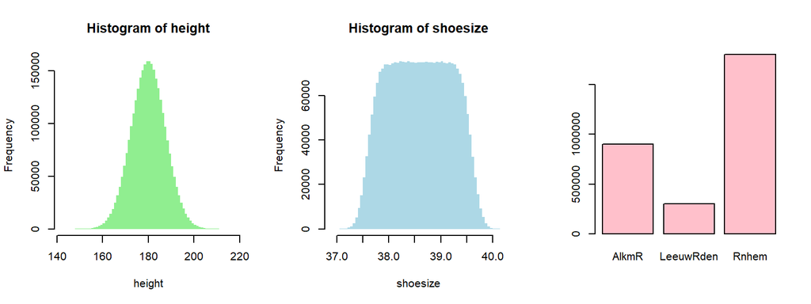

```r
par(mfrow = c(1,3))
hist(height,   breaks = 80, col = "light green", border = "transparent")
hist(shoesize, breaks = 80, col = "light blue",  border = "transparent")
table(city) %>% barplot(col = "pink")
```

(In a real country we will not know these things)

## Let’s do statistics!

We randomly sample 100 persons and “measure” their height, shoesize and city:

```r
samp100 <- sample(3e6, size = 100)
sdat100 <- sumR[samp100, ]
head(sdat100)
```

```
##           height shoesize      city
## 2908895 177.8716 39.28683     Rnhem
## 236907  170.2528 38.97513     Rnhem
## 1230916 195.9043 38.27168 LeeuwRden
## 1937234 177.4607 38.39331     Rnhem
## 2782743 172.3269 38.89885     AlkmR
## 2551759 169.6376 39.02313     Rnhem
```

Let’s use this sample to estimate quantities and infer things about our population!

## Goal

We want to know the mean height of our population

The sample mean \(\bar{x}\) is an estimator for the population mean \(\mu\)

```r
m <- mean(sdat100$height)
m
```

```
## [1] 179.7258
```

## The sampling distribution

## The sampling distribution: parametric

This statistic has a **sampling distribution**: taking a different sample generates a different mean value

Thus we have **uncertainty** about our estimated mean

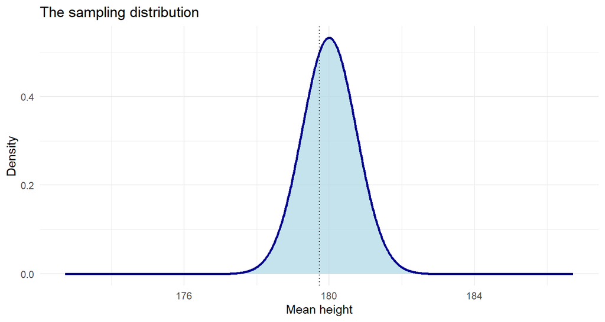

## The sampling distribution: parametric

- The sampling distribution of the mean is a normal distribution with *parameters*:
  - mean \(\mu_\bar{x}\)
  - standard deviation \(\sigma_\bar{x}\)
- We can estimate these quantities
- Mean estimator: sample mean \[\hat{\mu}_\bar{x} = \bar{x}\]
- Standard deviation estimator: the standard error \[\hat{\sigma}_\bar{x} = \frac{s_x}{\sqrt{n}}\]

```r
se <- sd(sdat100$height)/sqrt(100)
se
```

```
## [1] 0.6673471
```

## The sampling distribution: parametric

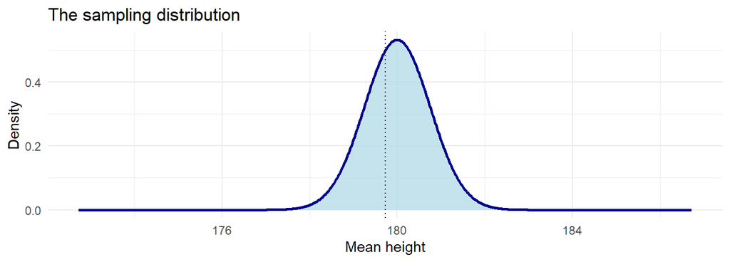

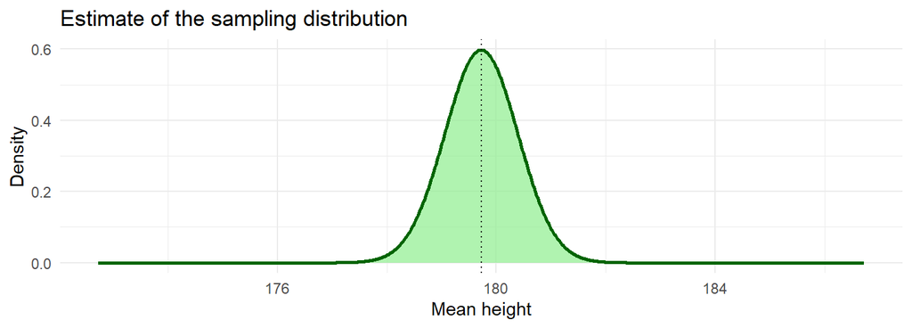

## Parametric Confidence Interval

Using the standard error and the assumption of normality, we can create a confidence interval (CI):

```r
(ci <- c(m - 1.96*se, m + 1.96*se))
```

```
## [1] 178.4178 181.0338
```

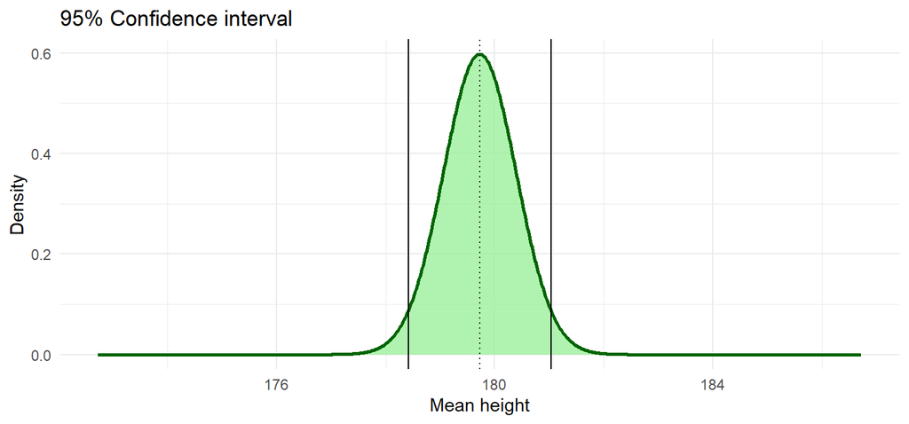

## The sampling distribution: parametric

### Interim conclusion

- Any sample statistic has **uncertainty** due to sampling
- This uncertainty is captured in the **sampling distribution**
- Asymptotically (as sample size grows) we assume it is a **normal distribution**
- The **standard error** is a measure of uncertainty
- Using the standard error, we can create a **95% CI**

## The sampling distribution: algorithmic

### Let’s take a step back

- The sampling distribution of a statistic is the distribution of its estimate upon infinitely repeated sampling.
- Since we have the full population, we can generate the sampling distribution ourselves!
- (but instead of infinite sampling, we sample 10 000 times)

```r
means <- numeric(10000)

for (i in 1:10000) {

  means[i] <- mean(sumR$height[sample(3e6, size = 100)])

}
```

## The sampling distribution: algorithmic

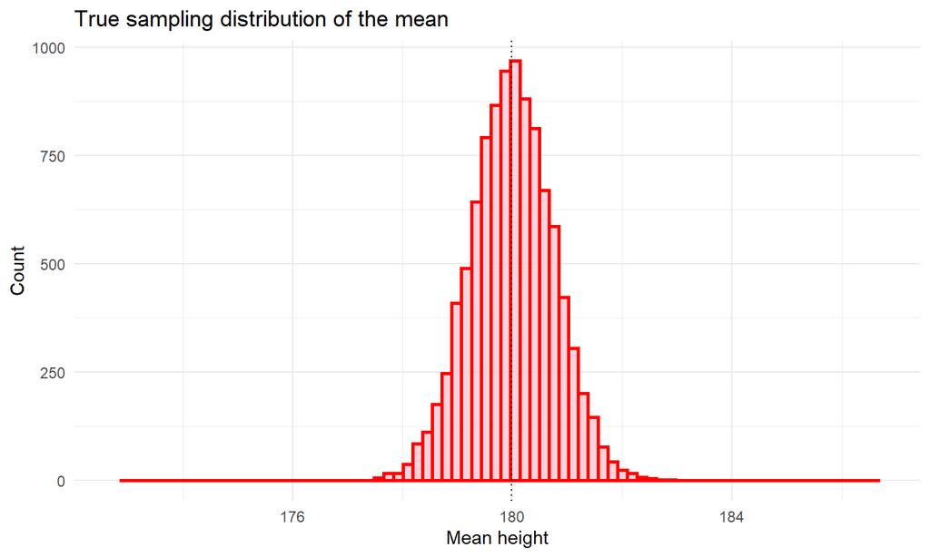

## Jackknife

In the 50s and 60s, computers enabled another measure of uncertainty

### The Jackknife

- take each person out of your sample once
- calculate the statistic on the remaining values
- the result: 100 slightly different means

```r
jknf <- numeric(100)

for (i in 1:100) jknf[i] <- mean(sdat100$height[-i])
```

Similar to LOOCV!

## Jackknife

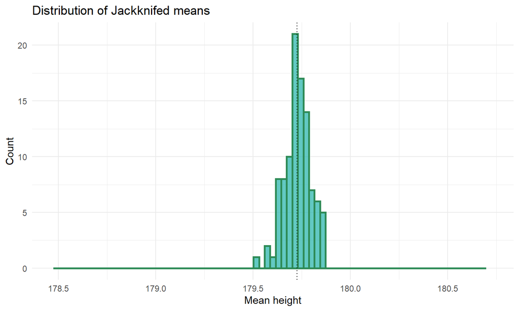

## Jackknife

The Jackknife can be used to estimate the standard error:

\[ \begin{align} \hat{se}_{j} &= \sqrt{\frac{n-1}{n}\sum_{i=1}^n\left(\hat{\theta}_{(i)}-\overline{\hat{\theta}_{(\cdot)}}\right)^2} \end{align}\]

```r
jkse <- sqrt(99/100*sum((jknf - mean(jknf))^2))
```

```
## Jackknife estimate: 0.667
## True standarderror: 0.750
```

With this, we can once again create a sampling distribution and a CI based on normal theory.

## Bootstrap

Introduced by Efron in 1979 as computers became more powerful.

- As many times as you like (e.g. 1000 times)
- Sample \(n\) values from your sample **with replacement**
- Calculate the statistic of interest on this **bootstrap sample**

```r
btsp <- numeric(1000)

for (i in 1:1000) btsp[i] <- mean(sdat100$height[sample(100, replace = TRUE)])
```

We sample from our sample, pulling ourselves “up” into the space of population by our bootstraps

## Bootstrap

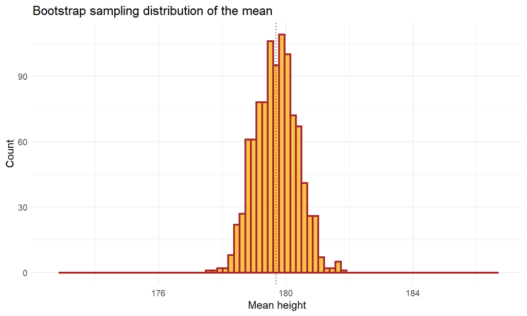

## Bootstrap approximation

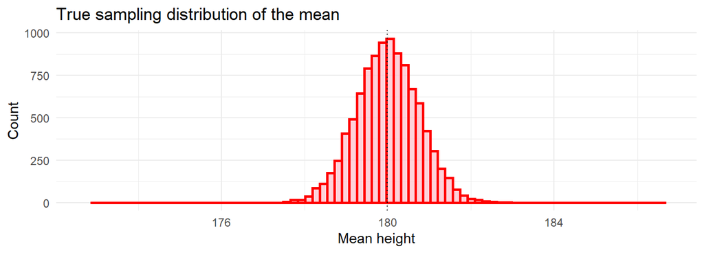

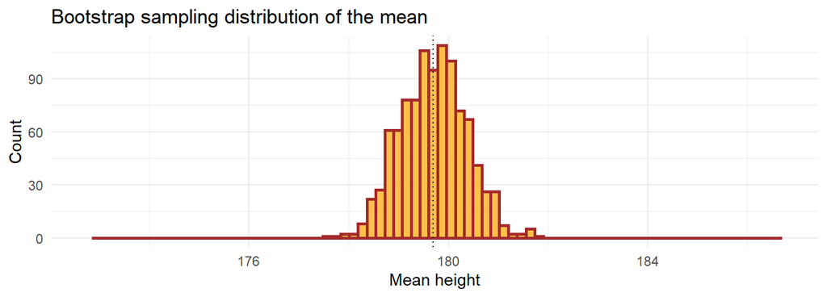

## Why?

### No more math!

The standard error calculation does not need to be known

### Relaxes the assumption of normality

For some quantities, unreasonable sample sizes are needed before normality (e.g. product of two regression coefficients in mediation analysis)

### Q: What is the sampling distribution of the log mean shoe size?

```r
log(mean(sdat100$shoesize))
```

```
## [1] 3.653499
```

## Log mean shoe size

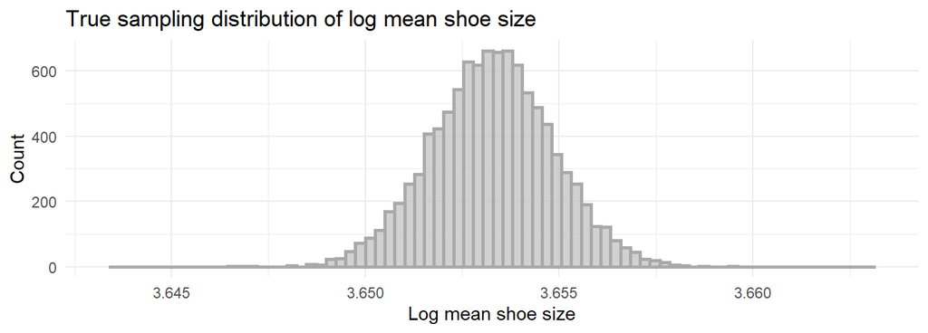

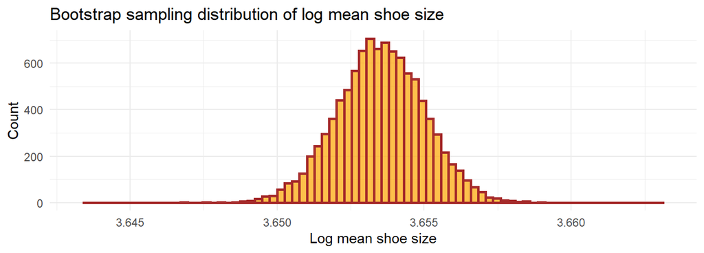

## Proportion of humans in LeeuwRden

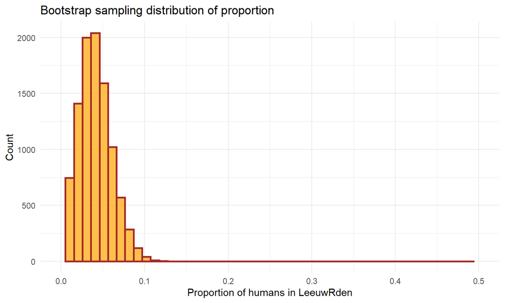

## The `boot` package

```r
mystat <- function(dat, index) {
  median(dat$height[index])/mean(dat$shoesize[index])
}

bootstat <- sdat100 %>% boot(mystat, R = 1000)

# the first 10 replicates
bootstat$t[1:10]
```

```
##  [1] 4.609170 4.646705 4.692967 4.600364 4.635099 4.635422 4.626590
##  [8] 4.624678 4.673900 4.599632
```

```r
# SE
sd(bootstat$t)
```

```
## [1] 0.02899687
```

## The `boot` package

```r
# 95% CI
boot.ci(bootstat)
```

```
## BOOTSTRAP CONFIDENCE INTERVAL CALCULATIONS
## Based on 1000 bootstrap replicates
##
## CALL :
## boot.ci(boot.out = bootstat)
##
## Intervals :
## Level      Normal              Basic
## 95%   ( 4.615,  4.729 )   ( 4.625,  4.727 )
##
## Level     Percentile            BCa
## 95%   ( 4.597,  4.699 )   ( 4.600,  4.703 )
## Calculations and Intervals on Original Scale
```

## The `boot` package

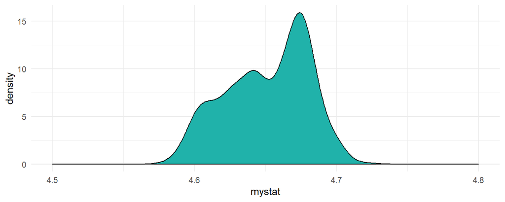

```r
# Distribution
data.frame(mystat = bootstat$t) %>%
  ggplot(aes(x = mystat)) +
  geom_density(fill = "light seagreen") +
  xlim(4.5, 4.8) +
  theme_minimal()
```

## Conclusion

- Sampling distribution indicates uncertainty
- Bootstrapping approximates the sampling distribution
- Treats sample as population to sample from
- Works when the shape of the sampling distribution is unknown
- Package `boot` can be used for bootstrapping